# An Introduction to [CHNOSZ](http://www.chnosz.net)

Jeffrey M. Dick

2019-05-11

# Overview

This document introduces the usage of CHNOSZ, a package for the [R software environment](http://r-project.org). For more information on R, see “[An Introduction to R](https://cran.r-project.org/manuals.html)” and the [contributed documentation](https://cran.r-project.org/other-docs.html) for R.

CHNOSZ has been developed since 2006 as a tool for thermodynamic calculations in geochemistry and compositional biology. The package provides functions and a thermodynamic database that can be used to calculate the stoichiometric and energetic properties of reactions involving minerals and inorganic and/or organic aqueous species. These functions also enable calculations of chemical affinities and metastable equilibrium distributions of proteins. A major feature of the package is the production of diagrams to visualize the effects of changing temperature, pressure, and activities of basis species on the potential for reactions among various species.

## Installing and loading CHNOSZ

After starting R, install CHNOSZ by selecting the “Install packages from CRAN” or similar menu item in the R GUI or by using the following command:

Or, install the package from a package file, which you can download from [CRAN](https://cran.r-project.org/package=CHNOSZ) or (for the development version) from [R-Forge](https://r-forge.r-project.org/projects/chnosz/).

```r
install.packages("CHNOSZ")
```

Then load the CHNOSZ package to make its functions available in your R session:

```r
library(CHNOSZ)
```

Then load the `thermo` object, which contains the thermodynamic database and system settings for CHNOSZ:

```r
data(thermo)
```

```
## data(thermo): attached environment "CHNOSZ"
```

```
## thermo$obigt: 1911 aqueous, 3588 total species
```

Note: Throughout this document, syntax highlighting is applied to the *input* of the code chunks. Double hash marks (`##`) precede the *output*, where black text denotes *results* and blue text is used for *messages*.

## Getting help

After CHNOSZ is installed, type `help.start()` to browse the R help documents, then choose “Packages” followed by “CHNOSZ”. That shows an index of the *manual* (help pages) for each function; many of the help pages include examples. There are also links to the *demos* (longer examples) and *vignettes* (more in-depth documentation; this document is a vignette).

Suggestions for accessing the documentation are indicated here with blue text. For example, read `` ?`CHNOSZ-package` `` to get an overview of the package and a list of features.

“`?`” is a shortcut to R’s `help()` function. The command here is equivalent to `help(“CHNOSZ-package”)`.

## Organization of major functions

CHNOSZ is made up of a set of functions and supporting datasets. The major components of the package are shown in the figure below, which is an updated version of the diagram in Dick (2008). Rectangles and ellipses represent functions and datasets; bold text indicates primary functions.

Dick JM. 2008. Calculation of the relative metastabilities of proteins using the CHNOSZ software package. *Geochemical Transactions* **9**: 10. doi: 10.1186/1467-4866-9-10

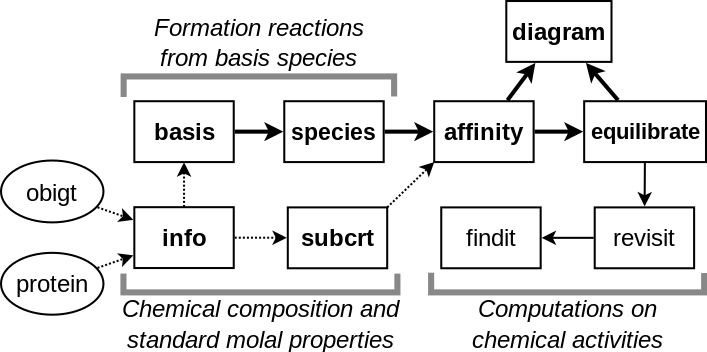

Structure of CHNOSZ.

Many functions in CHNOSZ have no side effects. That is, the function only returns a result; to use the result elsewhere, it can be assigned to a variable with `<-`. In this document, the names of these functions are set in green text (not applicable to the code chunks). Major functions without side effects in CHNOSZ are:

When they are mentioned, names of functions in the base and recommended packages of R are said to belong to R. Example: Use R’s `plot()` to plot the data.

- `info()`: search for species in the thermodynamic database;
- `subcrt()`: calculate the thermodynamic properties of species and reactions;
- `affinity()`: calculate the affinities of formation reactions using given chemical activities;
- `equilibrate()`: calculate the equilibrium chemical activities of the species of interest;
- `diagram()`: plot the results.

Some functions in CHNOSZ do have side effects: they modify the `thermo` data object in the current R session. In this document, the names of these functions are set in red text (but not in the code chunks). Major functions with side effects are:

- `basis()`: set the basis species and their chemical activities;
- `species()`: set the species of interest and their (non-equilibrium) chemical activities;
- `data(thermo)`: reset the database, restoring all settings to their default values.

The following pseudocode shows a common sequence of commands. In actual usage, the `...` are replaced by arguments that define the chemical species and variables:

```r
data(thermo)         ## initialize system settings
basis(...)
species(...)
a <- affinity(...)
e <- equilibrate(a)  ## optional
diagram(e)           ## or diagram(a)
data(thermo)         ## clear settings for next calculation
```

# The basics

- Use `info()` to search the thermodynamic database.

```r
info("aden ")
```

```
## info.approx: 'aden ' is ambiguous; has approximate matches to 6 species:
```

```
## [1] "adenine"        "adenosine"      "deoxyadenosine" "adenine"
## [5] "adenosine"      "deoxyadenosine"
```

```
## [1] NA
```

```r
info("adenine")
```

```
## info.character: found adenine(aq), also available in cr
```

```
## [1] 1675
```

```r
iadenine <- info("adenine")
```

```
## info.character: found adenine(aq), also available in cr
```

```r
info(iadenine)
```

```
##         name abbrv formula state        ref1  ref2      date     G     H     S
## 1675 adenine  <NA>  C5H5N5    aq LH06a [S07] LCT17 26.Jul.17 74770 31235 53.41
##         Cp    V    a1 a2     a3 a4    c1     c2   omega Z
## 1675 51.63 90.6 2.353  0 -17.75  0 48.54 -33180 -109300 0
```

- Use `thermo.refs()` to look up references.

```r
thermo.refs(iadenine)
```

```
##       key                                   author year
## 99  LH06a          D. E. LaRowe and H. C. Helgeson 2006
## 152 LCT17 A. R. Lowe, J. S. Cox and P. R. Tremaine 2017
##                                   citation
## 99  Geochim. Cosmochim. Acta 70, 4680-4724
## 152   J. Chem. Thermodynamics 112, 129-145
##                                                 note
## 99  nucleic-acid bases, nucleosides, and nucleotides
## 152                           adenine HKF parameters
##                                           URL
## 99  https://doi.org/10.1016/j.gca.2006.04.010
## 152 https://doi.org/10.1016/j.jct.2017.04.005
```

- Use `subcrt()` to calculate standard molal thermodynamic properties.

[figure not shown]

Nucleobase equal-activity diagram.

```r
subcrt("adenine", T = 100)
```

```
## info.character: found adenine(aq), also available in cr
```

```
## subcrt: 1 species at 373.15 K and 1.01 bar (wet)
```

```
## $species
##         name formula state ispecies
## 1675 adenine  C5H5N5    aq     1675
##
## $out
## $out$adenine
##     T       P      rho     logK     G       H       S       V      Cp
## 1 100 1.01322 0.958393 -41.1609 70279 35542.8 66.2548 98.5326 62.4799
```

[figure not shown]

Activities of nucleobases in metastable equilibrium.

- Use `basis()` – `species()` – `affinity()` – `diagram()` (BSAD) to construct equal-activity (equipotential) diagrams.

```r
basis("CHNOSe")
species(c("adenine", "cytosine", "guanine", "thymine", "uracil"))
a <- affinity(H2O = c(-12, -0), Eh = c(-0.5, 0), T = 100)
diagram(a)
```

- Use `equilibrate()` to calculate equilibrium activities.

```r
basis("e-", 3.6)
a <- affinity(H2O = c(-12, 0), T = 100)
e <- equilibrate(a)
diagram(e, ylim = c(-8, 0))
```

# Thermodynamic database

An attempt has been made to provide a primary database (OBIGT) that has no major inconsistencies. As the database includes datasets from many sources, it can not be guaranteed to be fully internally consistent. For crucial problems, check not only the accuracy of entries in the database, but also the *suitability of the data* for your problem. If there are any doubts, consult the primary sources. Use `thermo.refs()` to show a list of references for the data; see also the vignette, *Thermodynamic data in CHNOSZ*, for more information.

## The `info()` function

`info()` provides an interface to the thermodynamic database packaged with CHNOSZ. Suppose you are interested in the thermodynamic properties of aqueous methane. You can search for the species by name:

```r
info("methane")
```

```
## info.character: found methane(aq), also available in liq, gas
```

```
## [1] 859
```

Multiple entries exist for methane; the index of the `aq` (aqueous) species is returned by default. A second argument can be used to specify a different physical state:

```r
info("methane", "gas")
```

```
## [1] 3307
```

[output not shown]

Knowing that aqueous methane is species number 859 in the database, you can again use `info()` to retrieve the set of standard molal thermodynamic properties and equations of state parameters:

```r
info(methane)
```

[output not shown]

This number can be used as an argument (`ispecies`) for other functions in CHNOSZ to uniquely identify any species; some commonly used functions also accept the species names. Liquid water is species number 1; it has NA entries in the database because specialized functions are used to compute its properties:

```r
info(info("water"))
```

```
##    name abbrv formula state ref1 ref2      date  G  H  S Cp  V  a  b  c  d  e
## 1 water  <NA>     H2O   liq <NA> <NA> 25.Oct.06 NA NA NA NA NA NA NA NA NA NA
##    f lambda  T
## 1 NA     NA NA
```

## Fuzzy searches

Calling `info()` with a string that does not exactly match the name of any species invokes a fuzzy search of the database:

```r
info("acid")
```

```
## info.approx: 'acid' is ambiguous; has approximate matches to 84 species:
```

```
##  [1] "a-aminobutyric acid"     "acetamide"               "formic acid"             "acetic acid"             "propanoic acid"          "n-butanoic acid"
##  [7] "n-pentanoic acid"        "n-hexanoic acid"         "n-heptanoic acid"        "n-octanoic acid"         "n-nonanoic acid"         "n-decanoic acid"
## [13] "n-undecanoic acid"       "n-dodecanoic acid"       "n-benzoic acid"          "o-toluic acid"           "m-toluic acid"           "p-toluic acid"
## [19] "oxalic acid"             "malonic acid"            "succinic acid"           "glutaric acid"           "adipic acid"             "pimelic acid"
## [25] "suberic acid"            "azelaic acid"            "sebacic acid"            "glycolic acid"           "lactic acid"             "2-hydroxybutanoic acid"
## [31] "2-hydroxypentanoic acid" "2-hydroxyhexanoic acid"  "2-hydroxyheptanoic acid" "2-hydroxyoctanoic acid"  "2-hydroxynonanoic acid"  "2-hydroxydecanoic acid"
## [37] "aspartic acid"           "glutamic acid"           "cis-aconitic acid"       "isocitric acid"          "a-ketoglutaric acid"     "fumaric acid"
## [43] "malic acid"              "oxaloacetic acid"        "pyruvic acid"            "uracil"                  "citric acid"             "metacinnabar"
## [49] "sanidine,high"           "acide fulvique"          "acide humique"           "aspartic acid"           "glutamic acid"           "2-iodobenzoic acid"
## [55] "3-iodobenzoic acid"      "4-iodobenzoic acid"      "uracil"                  "phosphoric acid"         "citric acid"             "acetamide"
## [61] "nicotinamide,red"        "nicotinamide,ox"         "acetic acid"             "propanoic acid"          "n-butanoic acid"         "n-pentanoic acid"
## [67] "n-hexanoic acid"         "n-heptanoic acid"        "n-octanoic acid"         "n-nonanoic acid"         "n-decanoic acid"         "n-undecanoic acid"
## [73] "n-dodecanoic acid"       "n-tridecanoic acid"      "n-tetradecanoic acid"    "n-pentadecanoic acid"    "n-hexadecanoic acid"     "n-heptadecanoic acid"
## [79] "n-octadecanoic acid"     "n-nonadecanoic acid"     "n-eicosanoic acid"       "2-iodobenzoic acid"      "3-iodobenzoic acid"      "4-iodobenzoic acid"
```

```
## [1] NA
```

The message includes e.g. “uracil” and “metacinnabar” because their names have some similarity to the search term.

As “ribose” is the name of a species in the database, to find species with similar names, add an extra character to the search:

```r
info(" ribose")
```

```
## info.approx: ' ribose' is ambiguous; has approximate matches to 8 species:
```

```
## [1] "ribose"               "deoxyribose"          "ribose-5-phosphate"
## [4] "ribose-5-phosphate-1" "ribose-5-phosphate-2" "ribose"
## [7] "deoxyribose"          "ribose-5-phosphate"
```

```
## [1] NA
```

The messages may be useful for browsing the database, but owing to their ambiguous results, these fuzzy searches return an `NA` value for the species index.

## Counting elements, chemical formulas, `ZC()`

```r
info(methane)$formula
```

```
## [1] "C6H5CH3"
```

We can use `makeup()` to count the elements in the formula, followed by `as.chemical.formula()` to rewrite the formula on one line:

```r
makeup(methane)
```

```
## C H
## 7 8
```

```r
as.chemical.formula(makeup(methane))
```

```
## [1] "C7H8"
```

For organic species, a calculation of the average oxidation state of carbon (*Z*<sub>C</sub>) is possible given the species index, chemical formula, or elemental count:

```r
ZC(methane)
```

```
## [1] -1.14286
```

```r
ZC(info(methane)$formula)
```

```
## [1] -1.14286
```

```r
ZC(makeup(methane))
```

```
## [1] -1.14286
```

# Calculating thermodynamic properties

To calculate the standard molal properties of species and reactions, use `subcrt()`. <sup>(1992)</sup> If no reaction coefficients are given, `subcrt()` calculates the standard molal properties of individual species:

The inspiration for the name `subcrt()`, and the source of the Fortran subroutine used to calculate the thermodynamic properties of H<sub>2</sub>O, is SUPCRT (Johnson et al., 1992).

Johnson JW, Oelkers EH, Helgeson HC. 1992. SUPCRT92: A software package for calculating the standard molal thermodynamic properties of minerals, gases, aqueous species, and reactions from 1 to 5000 bar and 0 to 1000°C. *Computers & Geosciences* **18**(7): 899–947. doi: 10.1016/0098-3004(92)90029-Q

```r
subcrt("water")
```

```
## subcrt: 1 species at 15 values of T and P (wet)
```

```
## $species
##    name formula state ispecies
## 1 water     H2O   liq        1
##
## $out
## $out$water
##         T         P      rho    logK        G        H       S       V      Cp
## 1    0.01   1.00000 0.999829 45.0353 -56289.5 -68767.7 15.1324 18.0183 18.2056
## 2   25.00   1.00000 0.997061 41.5525 -56687.7 -68316.8 16.7123 18.0683 18.0116
## 3   50.00   1.00000 0.988030 38.6328 -57123.9 -67866.5 18.1623 18.2335 18.0046
## 4   75.00   1.00000 0.974864 36.1544 -57594.9 -67416.1 19.5048 18.4797 18.0416
## 5  100.00   1.01322 0.958393 34.0270 -58098.4 -66963.8 20.7596 18.7973 18.1579
## 6  125.00   2.32014 0.939073 32.1832 -58631.7 -66507.3 21.9419 19.1840 18.3333
## 7  150.00   4.75717 0.917058 30.5718 -59193.3 -66045.6 23.0640 19.6446 18.5664
## 8  175.00   8.91805 0.892343 29.1531 -59781.4 -65576.6 24.1360 20.1887 18.8830
## 9  200.00  15.53650 0.864743 27.8960 -60394.5 -65098.0 25.1682 20.8330 19.3288
## 10 225.00  25.47860 0.833873 26.7753 -61031.2 -64605.9 26.1712 21.6042 19.9704
## 11 250.00  39.73649 0.799072 25.7711 -61690.3 -64095.0 27.1569 22.5452 20.9123
## 12 275.00  59.43125 0.759236 24.8670 -62370.7 -63557.5 28.1400 23.7281 22.3513
## 13 300.00  85.83784 0.712408 24.0494 -63071.1 -62980.9 29.1407 25.2878 24.7394
## 14 325.00 120.45757 0.654577 23.3072 -63790.8 -62341.4 30.1952 27.5219 29.4475
## 15 350.00 165.21129 0.574688 22.6310 -64528.9 -61575.6 31.3971 31.3478 43.5985
```

That uses the default temperature and pressure settings, i.e. equally spaced temperature intervals from 0 to 350 °C at *P*<sub>sat</sub>. The columns in the output are temperature, pressure, density of water, logarithm of the equilibrium constant (only meaningful for reactions; see below), standard molal Gibbs energy and enthalpy of formation from the elements, standard molal entropy, volume, and heat capacity.

*P*<sub>sat</sub> is 1 bar below 100 °C, or the pressure of liquid-vapor saturation (i.e. boiling) at higher temperatures.

The corresponding units are °C (`T`), bar (`P`), g cm<sup>-3</sup> (`rho`), cal mol<sup>-1</sup> (`G` and `H`), cal K<sup>-1</sup> mol<sup>-1</sup> (`S` and `Cp`), and cm<sup>3</sup> mol<sup>-1</sup> (`V`).

A custom temperature-pressure grid can be specified. Here, we calculate the properties of H<sub>2</sub>O on a *T*, *P* grid in the supercritical region, with conditions grouped by pressure:

See also `demo(density)`.

```r
subcrt("water", T = c(400, 500, 600), P = c(200, 400, 600), grid = "P")$out$water
```

```
## subcrt: 1 species at 9 values of T and P (wet)
```

```
##     T   P       rho    logK        G        H       S        V      Cp
## 1 400 200 0.1005447 21.5271 -66306.4 -56639.3 39.0387 179.1760 27.4305
## 2 500 200 0.0677109 19.8868 -70353.7 -54819.8 41.5776 266.0607 14.0774
## 3 600 200 0.0550386 18.6704 -74593.1 -53540.0 43.1368 327.3197 11.9607
## 4 400 400 0.5236661 21.4119 -65951.4 -60454.4 32.8438  34.4021 37.5317
## 5 500 400 0.1779739 19.6639 -69565.0 -56252.5 38.7044 101.2238 24.9675
## 6 600 400 0.1238075 18.4124 -73562.4 -54361.7 41.0152 145.5098 15.4901
## 7 400 600 0.6124511 21.3631 -65801.3 -60832.4 32.0592  29.4149 25.8810
## 8 500 600 0.3384430 19.5660 -69218.6 -57694.2 36.3916  53.2296 32.4385
## 9 600 600 0.2071976 18.2784 -73027.2 -55195.1 39.4479  86.9469 19.3763
```

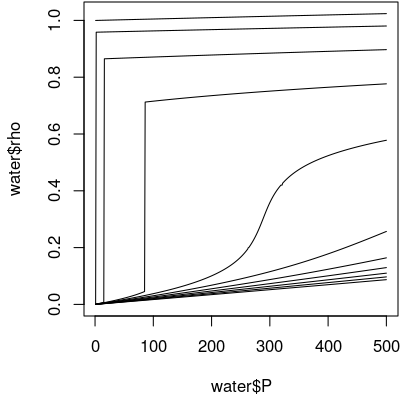

Isothermal contours of density (g cm<sup>-3</sup>) and pressure (bar) of water.

The additional operations (`$out$water`) are used to extract a specific part of the results; this can be used with e.g. R’s `write.table()` or `plot()` for further processing:

```r
substuff <- subcrt("water", T=seq(0,1000,100), P=c(NA, seq(1,500,1)), grid="T")
water <- substuff$out$water
plot(water$P, water$rho, type = "l")
```

## Changing units

The default units of temperature, pressure, and energy are °C, bar, and calories. The functions `T.units()`, `P.units()`, and `E.units()` can be used to change the units used by various functions in CHNOSZ. What is the Gibbs energy in J/mol of aqueous methane at 298.15 K and 0.1 MPa?

```r
T.units("K")
P.units("MPa")
E.units("J")
subcrt("methane", T = 298.15, P = 0.1)$out$methane$G
```

```
## [1] -34057.8
```

A related function, `convert()`, can be used to convert given values between units. Let’s convert the standard Gibbs energy of aqueous methane listed in the database from cal/mol to J/mol:

```r
convert(info(info("methane"))$G, "J")
```

```
## [1] -34057.8
```

As expected, we get the same result from both operations.

Use `data(thermo)` to restore the units and all other settings for CHNOSZ to their defaults:

```r
data(thermo)
```

```
## thermo$obigt: 1911 aqueous, 3588 total species
```

# Properties of reactions

## Reaction definitions

To calculate the thermodynamic properties of reactions, give the names of species, the physical states (optional), and reaction coefficients as the arguments to `subcrt()`. Here we calculate properties for the dissolution of CO<sub>2</sub>:

Because of aqueous speciation, this doesn’t give the *solubility* of CO<sub>2</sub>. For an example of a solubility calculation, see `demo(solubility)`, which is based on a figure in Manning et al. (2013).

```r
subcrt(c("CO2", "CO2"), c("gas", "aq"), c(-1, 1), T = seq(0, 250, 50))
```

```
## subcrt: 2 species at 6 values of T and P (wet)
```

```
## $reaction
##      coeff           name formula state ispecies
## 3308    -1 carbon dioxide     CO2   gas     3308
## 1576     1            CO2     CO2    aq     1576
##
## $out
##        T        P      rho     logK       G         H         S       V      Cp
## 1   0.01  1.00000 0.999829 -1.10873 1385.80 -5907.949 -26.70130 23.6978 49.1458
## 2  50.00  1.00000 0.988030 -1.71865 2541.27 -3947.724 -20.08036 36.9843 34.6260
## 3 100.00  1.01322 0.958393 -2.00354 3420.89 -2271.995 -15.25623 41.5584 33.0446
## 4 150.00  4.75717 0.917058 -2.10770 4080.94  -596.111 -11.05290 44.5642 34.3421
## 5 200.00 15.53650 0.864743 -2.09920 4544.74  1228.815  -7.00814 47.9553 39.3857
## 6 250.00 39.73649 0.799072 -2.01184 4815.90  3513.101  -2.49026 54.3882 55.7180
```

In order to make a plot like Figure 18 of Manning et al. (2013), let’s run more calculations and store the results. In addition to the reaction definition, we specify a greater number of temperature points than the default:

Manning CE, Shock EL, Sverjensky DA. 2013. The chemistry of carbon in aqueous fluids at crustal and upper-mantle conditions: Experimental and theoretical constraints. *Reviews in Mineralogy and Geochemistry* **75**(1): 109–148. doi: 10.2138/rmg.2013.75.5

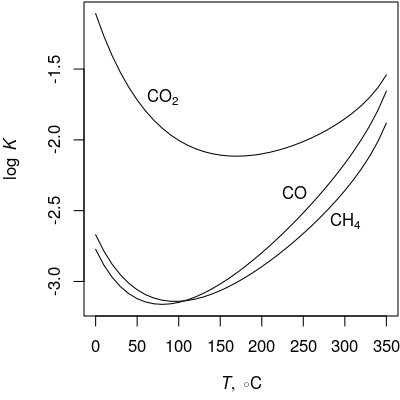

Calculated equilibrium constants for dissolution of CO<sub>2</sub>, CO, and CH<sub>4</sub>.

```r
T <- seq(0, 350, 10)
CO2 <- subcrt(c("CO2", "CO2"), c("gas", "aq"), c(-1, 1), T = T)$out$logK
CO <- subcrt(c("CO", "CO"), c("gas", "aq"), c(-1, 1), T = T)$out$logK
CH4 <- subcrt(c("CH4", "CH4"), c("gas", "aq"), c(-1, 1), T = T)$out$logK
logK <- data.frame(T, CO2, CO, CH4)
```

Now we can make the plot, using R’s `matplot()`. Here, `axis.label()` and `expr.species()` are used to create formatted axis labels and chemical formulas:

```r
matplot(logK[, 1], logK[, -1], type = "l", col = 1, lty = 1,
        xlab = axis.label("T"), ylab = axis.label("logK"))
text(80, -1.7, expr.species("CO2"))
text(240, -2.37, expr.species("CO"))
text(300, -2.57, expr.species("CH4"))
```

## Unbalanced reactions

A balanced chemical reaction conserves mass. `subcrt()` won’t stop you from running an unbalanced reaction, but it will give you a warning:

```r
subcrt(c("CO2", "CH4"), c(-1, 1))
```

```
## info.character: found CO2(aq), also available in gas
```

```
## info.character: found CH4(aq), also available in liq, gas
```

```
## subcrt: 2 species at 15 values of T and P (wet)
```

```
## subcrt: reaction is not balanced; it is missing this composition:
```

```
##  H  O
## -4  2
```

In other words, to balance the reaction, we should add 4 H to the left and 2 O to the right. That could be done manually be redefining the reaction with the appropriate species. There is another option: balancing the reaction automatically using basis species.

## Setting the basis species

*Basis species* are a minimal number of chemical species that linearly combine to give the composition of any species in the system. The basis species are similar to thermodynamic components, but can include charged species. Basis species are used in CHNOSZ to automatically balance reactions; they are also required for making chemical activity diagrams.

Let’s start with an example that doesn’t work:

```r
basis(c("CO2", "H2", "H2CO2"))
```

```
## Error in put.basis(ispecies, logact): singular stoichiometric matrix
```

That set of species has a singular (non-invertible) stoichiometric matrix. An error would also result from either an underdetermined or overdetermined system. A valid set of basis species has an invertible stoichiometric matrix and the same number of species as elements:

```r
basis(c("CO2", "H2", "H2O"))
```

```
##     C H O ispecies logact state
## CO2 1 0 2     1576      0    aq
## H2  0 2 0       64      0    aq
## H2O 0 2 1        1      0   liq
```

The composition of any species made up of C, H, and O can be represented by a single linear combination of these basis species.

## Automatically balancing reactions

Methanogenic metabolism in reducing environments may proceed by acetoclastic or hydrogenotrophic processes. To consider reactions involving a charged species (acetate), let’s define a basis with H<sup>+</sup>:

```r
basis(c("CO2", "H2", "H2O", "H+"))
```

```
##     C H O Z ispecies logact state
## CO2 1 0 2 0     1576      0    aq
## H2  0 2 0 0       64      0    aq
## H2O 0 2 1 0        1      0   liq
## H+  0 1 0 1        3      0    aq
```

By identifying species *other than* the basis species, the reactions will be automatically balanced. This produces the balanced reaction for acetoclastic methanogenesis:

```r
subcrt(c("acetate", "methane"), c(-1, 1))$reaction
```

```
##      coeff    name formula state ispecies
## 1070    -1 acetate C2H3O2-    aq     1070
## 859      1 methane     CH4    aq      859
## 1576     1     CO2     CO2    aq     1576
## 3       -1      H+      H+    aq        3
```

We can similarly consider reactions for hydrogenotrophic methanogenesis as well as acetate oxidation (without production of methane):

```r
acetate_oxidation <- subcrt("acetate", -1)
hydrogenotrophic <- subcrt("methane", 1)
acetoclastic <- subcrt(c("acetate", "methane"), c(-1, 1))
```

Use `describe.reaction()` to write the reactions on a plot:

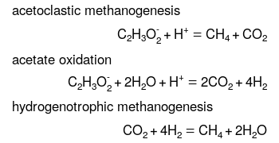

```r
plot(0, 0, type = "n", axes = FALSE, ann=FALSE, xlim=c(0, 5), ylim=c(5.2, -0.2))
text(0, 0, "acetoclastic methanogenesis", adj = 0)
text(5, 1, describe.reaction(acetoclastic$reaction), adj = 1)
text(0, 2, "acetate oxidation", adj = 0)
text(5, 3, describe.reaction(acetate_oxidation$reaction), adj = 1)
text(0, 4, "hydrogenotrophic methanogenesis", adj = 0)
text(5, 5, describe.reaction(hydrogenotrophic$reaction), adj = 1)
```

## Chemical affinity

Usually, `subcrt()` returns only standard state thermodynamic properties. Thermodynamic models often consider a non-standard state (i.e. non-unit activity). The activities of basis species can be modified with `basis()`, and those of the other species using the `logact` argument in `subcrt()`.

The standard state adopted for H<sub>2</sub>O is unit activity of the pure component at any *T* and *P*. The standard state for aqueous species is unit activity of a hypothetical one molal solution referenced to infinite dilution at any *T* and *P*.

The affinity is equal to the negative of the overall (non-standard) Gibbs energy change of the reaction.

Mayumi D, Dolfing J, Sakata S, Maeda H, Miyagawa Y, Ikarashi M, Tamaki H, Takeuchi M, Nakatsu CH, Kamagata Y. 2013. Carbon dioxide concentration dictates alternative methanogenic pathways in oil reservoirs. *Nature Communications* **4**: 1998. doi: 10.1038/ncomms2998

```r
E.units("J")
basis(c("CO2", "H2", "H2O", "H+"))
basis(c("CO2", "H2"), "gas")
basis(c("H2", "pH"), c(-3.92, 7.3))
```

```r
subcrt(c("acetate", "methane"), c(-1, 1),
       c("aq", "gas"), logact = c(-3.4, -0.18), T = 55, P = 50)$out
```

```
##    T  P      rho    logK        G       H       S        V      Cp  logQ
## 1 55 50 0.987821 13.5984 -85429.6 18706.9 317.685 -40.1339 39.2144 10.52
##         A
## 1 19339.4
```

The new `A` column shows the affinity; the other columns are unaffected and still show the standard-state properties. Let’s repeat the calculation for hydrogenotrophic methanogenesis.

```r
subcrt("methane", 1, "gas", logact = -0.18, T = 55, P = 50)$out
```

```
##    T  P      rho   logK       G       H        S       V      Cp logQ       A
## 1 55 50 0.987821 18.828 -118284 -251807 -407.195 36.4746 33.4702 15.5 20907.8
```

Under the specified conditions, the affinities of hydrogenotrophic and acetoclastic methanogenesis are somewhat greater than and less than 20 kJ, respectively. This result matches Figure 4b in Mayumi et al. (2013) at unit fugacity of CO<sub>2</sub>.

We can go even further and reproduce their plot. To make the code neater, we write a function that can run any of the reactions:

The reproduction is not identical, owing to differences of thermodynamic data and of calculations of the effects of temperature and pressure.

```r
rxnfun <- function(coeffs) {
  subcrt(c("acetate", "methane"), coeffs,
         c("aq", "gas"), logact = c(-3.4, -0.18), T = 55, P = 50)$out
}
```

Now we’re ready to calculate and plot the affinities. Here, we use R’s `lapply()` to list the results at two values of logarithm of fugacity of CO<sub>2</sub>. We insert an empty reaction to get a line at zero affinity. R’s `do.call()` and `rbind()` are used to turn the list into a data frame that can be plotted with R’s `matplot()`. There, we plot the negative affinities, equal to Gibbs energy, as shown in the plot of Mayumi et al. (2013).

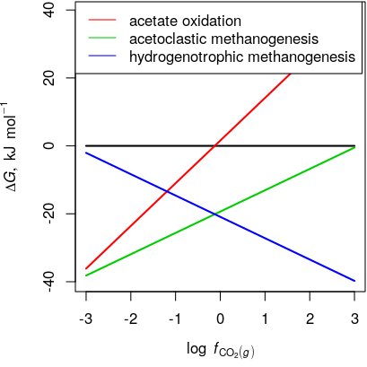

Gibbs energies of acetate oxidation and methanogenesis (after Mayumi et al., 2013).

```r
Adat <- lapply(c(-3, 3), function(logfCO2) {
  basis("CO2", logfCO2)
  data.frame(logfCO2,
    rxnfun(c(0, 0))$A,
    rxnfun(c(-1, 0))$A,
    rxnfun(c(-1, 1))$A,
    rxnfun(c(0, 1))$A
  )
})
Adat <- do.call(rbind, Adat)
matplot(Adat[, 1], -Adat[, -1]/1000, type = "l", lty = 1, lwd = 2,
  xlab = axis.label("CO2"), ylab = axis.label("DG", prefix = "k"))
legend("topleft", c("acetate oxidation", "acetoclastic methanogenesis",
  "hydrogenotrophic methanogenesis"), lty = 1, col = 2:4)
```

Let’s not forget to clear the system settings, which were modified by `basis()` and `E.units()`, before running other calculations:

```r
data(thermo)
```

# Using `affinity()`

`affinity()` offers calculations of chemical affinity of formation reactions over a configurable range of *T*, *P*, and activities of basis species.

## Species of interest

By *formation reaction* is meant the stoichiometric requirements for formation of one mole of any species from the basis species. The `species()` function is used to set these *species of interest*. Let’s consider the stoichiometry of some aqueous sulfur-bearing species. Here we use `basis()` with a keyword to load a preset basis definition.

Some available keywords are `CHNOS` (including CO<sub>2</sub>, H<sub>2</sub>O, NH<sub>3</sub>, H<sub>2</sub>S, and O<sub>2</sub>), `CHNOS+` (also including H<sup>+</sup>), and `CHNOSe` (including H<sup>+</sup>, and *e*<sup>-</sup> instead of O<sub>2</sub>). See `?basis` for more options.

What is `SO42-`? Is it 1 S, 4 O, and 2 negative charges, or 1 S, 42 O, and 1 negative charge? The ambiguity of a digit that could belong to the coefficient for the following charge or to that for the preceding element is why formulas in CHNOSZ are written with the number of charges after the + or - symbol. `SO4-2` is unambiguously parsed as 1 S, 4 O and 2 negative charges.

```r
basis("CHNOS+")
```

```r
species(c("H2S", "HS-", "HSO4-", "SO4-2"))
```

```
##   CO2 H2O NH3 H2S O2 H+ ispecies logact state  name
## 1   0   0   0   1  0  0       67     -3    aq   H2S
## 2   0   0   0   1  0 -1       22     -3    aq   HS-
## 3   0   0   0   1  2 -1       25     -3    aq HSO4-
## 4   0   0   0   1  2 -2       24     -3    aq SO4-2
```

Aqueous species are assigned default activities of 10<sup>-3</sup> (`logact` is -3). Now, we can use `affinity()` to calculate the affinities of the formation reactions of each of the species. R’s `unlist()` is used here to turn the list of values of affinity into a numeric object that can be printed in a couple of lines (note that the names correspond to `ispecies` above):

The values returned by `affinity()` are dimensionless, i.e. *A*/(2.303*RT*).

```r
unlist(affinity()$values)
```

```
## energy.args: temperature is 25 C
```

```
## energy.args: pressure is Psat
```

```
## subcrt: 10 species at 298.15 K and 1 bar (wet)
```

```
##        67        22        25        24
##  -4.00000  -3.98775 -29.48836 -24.46748
```

The same result (but expressed in units of cal/mol or J/mol) could be obtained using `subcrt()`; however, `affinity()` has the advantage of being able to perform calculations on a grid of *T*, *P*, or activities of basis species. Let’s choose a set of variables commonly used in aqueous speciation diagrams: Eh and pH. To use Eh as a variable, the electron (*e*<sup>-</sup>) should be in the basis. To put the electron in there, we can use a different keyword (`basis("CHNOSe")`), or swap oxygen out of the existing basis:

```r
swap.basis("O2", "e-")
```

```
## subcrt: 6 species at 298.15 K and 1 bar (wet)
## subcrt: 6 species at 298.15 K and 1 bar (wet)
```

```
##     C H N O S  Z ispecies   logact state
## CO2 1 0 0 2 0  0     1576 -3.00000    aq
## H2O 0 2 0 1 0  0        1  0.00000   liq
## NH3 0 3 1 0 0  0       66 -4.00000    aq
## H2S 0 2 0 0 1  0       67 -7.00000    aq
## e-  0 0 0 0 0 -1        2  6.22377    aq
## H+  0 1 0 0 0  1        3 -7.00000    aq
```

`swap.basis()` changed the basis species and recalculated their activities, but preserved the species of interest.

That is, running `affinity()``$values` again would give the same result.

Now we can calculate the affinities on an Eh-pH grid:

```r
a <- affinity(pH = c(0, 12), Eh = c(-0.5, 1))
```

```
## energy.args: temperature is 25 C
```

```
## energy.args: pressure is Psat
```

```
## energy.args: variable 1 is pH at 128 values from 0 to 12
```

```
## energy.args: variable 2 is Eh at 128 values from -0.5 to 1 V
```

```
## subcrt: 10 species at 298.15 K and 1 bar (wet)
```

[output not shown]

[output not shown]

```
## subcrt: 3 species at 298.15 K and 1 bar (wet)
```

```
## info.character: found H2O(liq), also available in cr
```

```
## subcrt: 4 species at 298.15 K and 1 bar (wet)
```

```
## subcrt: 2 species at 298.15 K and 1 bar
```

```
## info.character: found H2O(liq), also available in cr
```

```
## subcrt: 4 species at 298.15 K and 1 bar (wet)
```

```
## subcrt: 3 species at 298.15 K and 1 bar (wet)
```

```
## info.character: found H2O(liq), also available in cr
```

```
## subcrt: 4 species at 298.15 K and 1 bar (wet)
```

```
## subcrt: 2 species at 298.15 K and 1 bar
```

```
## info.character: found H2O(liq), also available in cr
```

```
## subcrt: 4 species at 298.15 K and 1 bar (wet)
```

## Potential diagrams

Given values of affinity, the `diagram()` function uses the maximum affinity method to make a potential diagram (i.e. a Pourbaix diagram). Areas corresponding to Eh-pH conditions beyond the stability limits of water are colored slate gray. Another function, `water.lines()`, is used to draw lines at the water stability limits:

[output not shown]

[output not shown]

[output not shown]

[output not shown]

[output not shown]

```r
diagram(a, fill = "heat")
```

```
## balance: from moles of H2S in formation reactions
```

```
## diagram: plotting A/(2.303RT) / n.balance (maximum affinity method for 2-D diagrams)
```

```
## subcrt: 3 species at 298.15 K and 1 bar (wet)
```

```
## info.character: found H2O(liq), also available in cr
```

```
## subcrt: 4 species at 298.15 K and 1 bar (wet)
```

```
## subcrt: 2 species at 298.15 K and 1 bar
```

```
## info.character: found H2O(liq), also available in cr
```

```
## subcrt: 4 species at 298.15 K and 1 bar (wet)
```

```r
water.lines(a)
```

```
## subcrt: 3 species at 298.15 K and 1 bar (wet)
```

```
## info.character: found H2O(liq), also available in cr
```

```
## subcrt: 4 species at 298.15 K and 1 bar (wet)
```

```
## subcrt: 2 species at 298.15 K and 1 bar
```

```
## info.character: found H2O(liq), also available in cr
```

```
## subcrt: 4 species at 298.15 K and 1 bar (wet)
```

Note that the calculation of affinity implies a non-equilibrium reference state of equal activities of species (see above). Generally, then, `diagram()` gives a *potential diagram* because it shows regions of maximum affinity. In systems where equilibrium is attainable, it makes sense to call this a *predominance diagram*, showing regions of maximum activity.

[figure not shown]

The same plot, with different colors and labels.

The names of species that can be parsed as chemical formulas are formatted with subscripts and superscripts; if this is not desired, set `format.names = FALSE`. The default colors for diagrams shown on the screen use R’s `heat.colors()` palette. Some arguments in `diagram()` can be used to control the color, labels, and lines, and title. The `tplot` argument turns off plot customizations used in CHNOSZ. Additional arguments are passed to R’s plotting functions; here, we use `bty` to remove the box around the plot.

```
## balance: from moles of H2S in formation reactions
```

```
## diagram: plotting A/(2.303RT) / n.balance (maximum affinity method for 2-D diagrams)
```

```
## subcrt: 3 species at 298.15 K and 1 bar (wet)
```

```
## info.character: found H2O(liq), also available in cr
```

```
## subcrt: 4 species at 298.15 K and 1 bar (wet)
```

```
## subcrt: 2 species at 298.15 K and 1 bar
```

```
## info.character: found H2O(liq), also available in cr
```

```
## subcrt: 4 species at 298.15 K and 1 bar (wet)
```

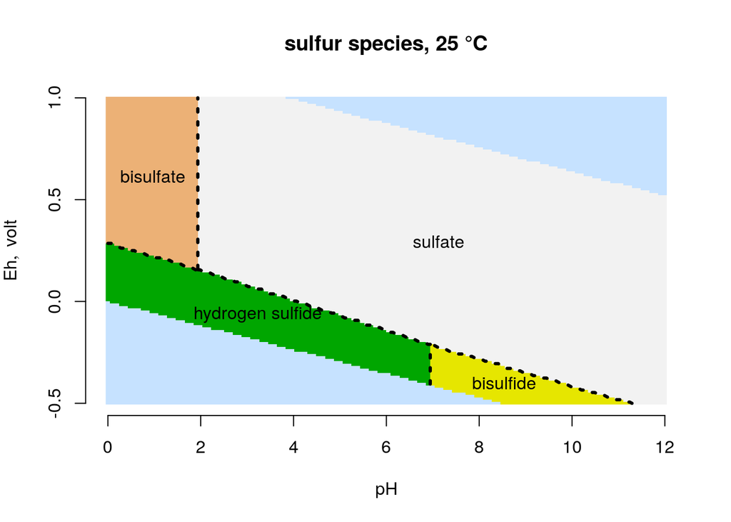

```r
diagram(a, fill = "terrain", lwd = 3, lty = 3,
        names = c("hydrogen sulfide", "bisulfide", "bisulfate", "sulfate"),
        tplot = FALSE, main = "sulfur species, 25 °C", bty = "n")
```

Mineral stability diagrams often depict activity ratios, e.g. log (*a*<sub>Ca<sup>+2</sup></sub>/*a*<sub>H<sup>+</sup></sub><sup>2</sup>), on one or both axes. The variables used for potential calculations in CHNOSZ include only a single chemical activity, e.g. log *a*<sub>Ca<sup>+2</sup></sub>. However, you can set pH = 0 to generate diagrams that are geometrically equivalent to those calculated using activity ratios, and use `ratlab()` to make the axes labels for the ratios. See `demo(activity_ratios)` for some examples.

## Mosaic diagrams

If sulfur is in the basis species, then we should consider that its speciation is sensitive to Eh and pH, as shown in the preceding diagram. Mosaic diagrams, which are often shown for oxide, sulfide, and carbonate minerals, account for speciation of the basis species. These diagrams are made by constructing individual diagrams for the possible basis species. The individual diagrams are then combined, each one contributing to the final diagram only in the range of stability of the corresponding basis species.

Let’s use `mosaic()` to make a diagram for aqueous species and minerals in the Cu-S-Cl-H<sub>2</sub>O system, similar to Figure 5a of Caporuscio et al. (2017). To know what aqueous copper chloride complexes are available in the database, we can use a fuzzy search:

Caporuscio FA, Palaich SEM, Cheshire MC, Jové Colón CF. 2017. Corrosion of copper and authigenic sulfide mineral growth in hydrothermal bentonite experiments. *Journal of Nuclear Materials* **485**: 137–146. doi: 10.1016/j.jnucmat.2016.12.036

```r
info(" CuCl")
```

```
## info.approx: ' CuCl' is ambiguous; has approximate matches to 7 species:
```

```
## [1] "CuCl"    "CuCl2-"  "CuCl3-2" "CuCl+"   "CuCl2"   "CuCl3-"  "CuCl4-2"
```

We wish to include chalcocite (Cu<sub>2</sub>S) in the system. This mineral undergoes phase transitions; to find out the temperatures of the phase transitions, we can also use `info()`:

```r
info(info("chalcocite", c("cr", "cr2", "cr3")))$T
```

```
## [1]  376  717 1400
```

Those are temperatures in Kelvin (regardless of the `T.units()`); at 200 °C we should use the second phase.

Next we define the basis, and set the activities of the H<sub>2</sub>S and Cl<sup>-</sup> basis species. These represent the total activity of S and Cl in the system, which are distributed among the minerals and aqueous species. Three minerals and the aqueous copper chloride species are included:

```r
basis(c("Cu", "H2S", "Cl-", "H2O", "H+", "e-"))
basis("H2S", -6)
basis("Cl-", -0.7)
species(c("copper", "tenorite"))
species("chalcocite", "cr2")
species(c("CuCl", "CuCl2-", "CuCl3-2", "CuCl+", "CuCl2", "CuCl3-", "CuCl4-2"))
```

We use `mosaic()` to generate and combine diagrams for each candidate basis species (H<sub>2</sub>S, HS<sup>-</sup>, HSO<sub>4</sub><sup>-</sup>, or SO<sub>4</sub><sup>-2</sup>) as a function of Eh and pH. The key argument is `bases`, which identifies the candidate basis species, starting with the one in the current basis. The other arguments, like those of `affinity()`, specify the ranges of the variables; `res` indicates the grid resolution to use for each variable (the default is 128). The first call to `diagram()` plots the species of interest; the second adds the predominance fields of the basis species. We turn off the gray coloring beyond the water stability limits (`limit.water`) but plot the red dotted lines using `water.lines()`:

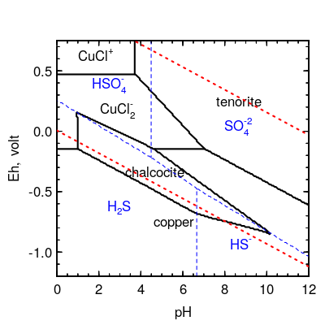

Copper minerals and aqueous complexes with chloride, 200 °C.

```r
T <- 200
res <- 200
bases <- c("H2S", "HS-", "HSO4-", "SO4-2")
m1 <- mosaic(bases, blend = TRUE, pH = c(0, 12, res), Eh=c(-1.2, 0.75, res), T=T)
diagram(m1$A.species, lwd = 2, fill = NA, limit.water = FALSE)
diagram(m1$A.bases, add = TRUE, col = "blue", col.names = "blue", lty = 2,
        limit.water = FALSE)
water.lines(m1$A.species, col = "red", lwd = 2, lty = 3)
```

The argument `blend = TRUE` is used to combine the diagrams according to the equilibrium activities of the basis species by themselves (see below). The smooth transitions between basis species cause the appearance of curved lines on the plot. Without that argument, the diagrams would be combined using the dominant basis species, and all of the line segments would be straight.

We have seen the effects of speciation of S in the basis species. However, the choice of other basis species can also affect the diagram. For instance, we can use H<sub>2</sub> or O<sub>2</sub> in place of *e*<sup>-</sup>. To do that, let’s write a function to swap those basis species and make a diagram. We use R’s `do.call()` to construct the argument list for `mosaic()`; this way, the name of the `newvar` argument to our function indicates the chosen variable.

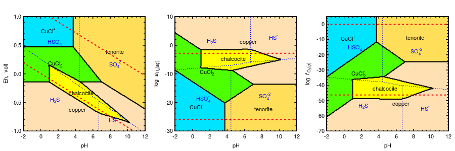

The same chemical system projected into different sets of basis species.

```r
mosaicfun <- function(newvar, T = 200) {
  swap.basis("e-", names(newvar))
  if (names(newvar) == "O2") basis("O2", "gas")
  mosaicargs <- c(list(bases), blend=TRUE, pH=list(c(-2, 12, res)), newvar, T=T)
  m1 <- do.call(mosaic, mosaicargs)
  diagram(m1$A.species, lwd = 2, fill = rev(topo.colors(10)),
          limit.water = FALSE)
  diagram(m1$A.bases, add = TRUE, col = "blue", col.names = "blue", lty = 3,
          limit.water = FALSE)
  water.lines(m1$A.species, col = "red", lwd = 2, lty = 3)
  swap.basis(names(newvar), "e-")
}
par(mfrow = c(1, 3))
mosaicfun(list(Eh = c(-1, 1, res)))
mosaicfun(list(H2 = c(-30, 10, res)))
mosaicfun(list(O2 = c(-70, 5, res)))
```

## *T*, *P*, activity transects

Above, we used evenly-spaced grids of chemical activities of basis species; the ranges of variables were given by two or three values (minimum, maximum, and optionally resolution). `affinity()` can also perform calculations along a transect, i.e. a particular path along one or more variables. A transect is calculated when there are four or more values assigned to the variable(s). Let’s use this feature to calculate affinities (negative Gibbs energies) of methanogenesis and biosynthetic reactions in a hydrothermal system.

Some results of mixing calculations for seawater and vent fluid from the Rainbow hydrothermal field, calculated using EQ3/6 by Shock and Canovas (2010), are included in a data file in CHNOSZ. Reading the file with R’s `read.csv()`, we set `check.names = FALSE` to preserve the `NH4+` column name (which is not a syntactically valid variable name):

Shock E, Canovas P. 2010. The potential for abiotic organic synthesis and biosynthesis at seafloor hydrothermal systems. *Geofluids* **10**(1-2): 161–192. doi: 10.1111/j.1468-8123.2010.00277.x

```r
file <- system.file("extdata/cpetc/SC10_Rainbow.csv", package = "CHNOSZ")
rb <- read.csv(file, check.names = FALSE)
```

We take a selection of the species from Shock and Canovas (2010) with activities equal to 10<sup>-6</sup>; methane is assigned an activity of 10<sup>-3</sup>. We will write the synthesis reactions of organic species in terms of these basis species:

The constant activity of methane is a simplification of the calculation reported by Shock and Canovas (2010). The code here could be expanded to vary the activity of methane.

```r
basis(c("CO2", "H2", "NH4+", "H2O", "H2S", "H+"))
species("CH4", -3)
species(c("adenine", "cytosine", "aspartic acid", "deoxyribose",
          "methane", "leucine", "tryptophan", "n-nonanoic acid"), -6)
```

Now we can calculate affinities along the transect of changing temperature and activities of five basis species. Each variable is given as a named argument; `NH4+` must be quoted. Using R’s `lapply()` to run `convert()` for each species, we convert the affinity from dimensionless values (*A*/(2.303*RT*)) to cal/mol, then kcal/mol.

A shorter expression would use R’s `do.call()` to construct the function call: `do.call(``affinity``, as.list(rb))`.

The target of the conversion is `G`, or free energy, from `logK`. That conversion requires temperature in Kelvin, which is obtained by conversion from °C. We finish with a negation (affinity is negative Gibbs energy) and scaling from cal to kcal.

```r
a <- affinity(T = rb$T, CO2 = rb$CO2, H2 = rb$H2,
              `NH4+` = rb$`NH4+`, H2S = rb$H2S, pH = rb$pH)
T <- convert(a$vals[[1]], "K")
a$values <- lapply(a$values, convert, "G", T)
a$values <- lapply(a$values, `*`, -0.001)
```

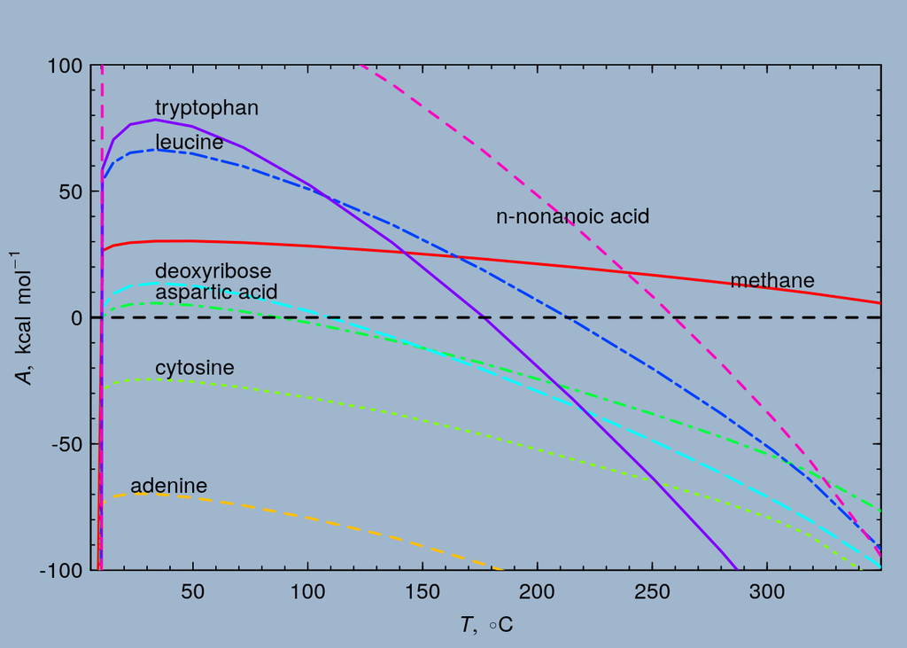

Affinities of organic synthesis in a hydrothermal system, after Shock and Canovas (2010).

Finally, we use `diagram()` to plot the results. Although only temperature is shown on the *x* axis, pH and the activities of CO<sub>2</sub>, H<sub>2</sub>, NH<sub>4</sub><sup>+</sup>, and H<sub>2</sub>S are also varied according to the data in `rb`. By default, `diagram()` attempts to scale the affinities by dividing by the reaction coefficients of a shared basis species (in this case, CO<sub>2</sub>). To override that behavior, we set `balance = 1` to plot the affinities of the formation reactions as written (per mole of the product species).

```r
diagram(a, balance = 1, ylim = c(-100, 100), ylab = axis.label("A", prefix="k"),
        col = rainbow(8), lwd = 2, bg = "slategray3")
```

```
## balance: from numeric argument value
```

```
## diagram: plotting A/(2.303RT) / n.balance (maximum affinity method for 2-D diagrams)
```

[figure not shown]

```r
abline(h = 0, lty = 2, lwd = 2)
```

When making line plots, `diagram()` automatically places the labels near the lines. The additional arguments `adj` and `dy` can be used to fine-tune the positions of the labels (they are used in a couple of examples below). If labeling of the lines is not desired, add e.g. `legend.x = "topright"` to make a legend instead, or `names = NULL` to prevent any plotting of the names.